# Optimal Treatment Analysis

## Outcome Variable

**Outcome Variable:** ever_wasted

## Predictor Variables

**Intervention Variable:** exclfeed36

**Adjustment Set:**

- arm
- sex
- W_mage
- meducyrs
- feducyrs
- hhwealth_quart
- hfoodsec
- W_mhtcm
- vagbrth
- W_gagebrth
- W_birthwt
- W_birthlen
- W_nrooms
- W_nchldlt5
- month
- brthmon
- W_parity
- impfloor
- impsan
- safeh20
- delta_W_mage
- delta_meducyrs
- delta_feducyrs
- delta_hhwealth_quart
- delta_hfoodsec
- delta_W_mhtcm
- delta_vagbrth
- delta_W_gagebrth
- delta_W_birthwt
- delta_W_birthlen
- delta_W_nrooms
- delta_W_nchldlt5
- delta_month
- delta_brthmon
- delta_W_parity
- delta_impfloor
- delta_impsan
- delta_safeh20

## Stratifying Variables

The analysis was stratified on these variable(s):

- agecat
- studyid
- country

## Data Summary

| agecat | studyid | country | exclfeed36 | ever_wasted | n_cell | n |
| --- | --- | --- | --- | --- | --- | --- |
| 0-24 months (no birth wast) | ki0047075b-MAL-ED | BANGLADESH | 1 | 0 | 47 | 251 |
| 0-24 months (no birth wast) | ki0047075b-MAL-ED | BANGLADESH | 1 | 1 | 17 | 251 |
| 0-24 months (no birth wast) | ki0047075b-MAL-ED | BANGLADESH | 0 | 0 | 147 | 251 |
| 0-24 months (no birth wast) | ki0047075b-MAL-ED | BANGLADESH | 0 | 1 | 40 | 251 |
| 0-24 months (no birth wast) | ki0047075b-MAL-ED | BRAZIL | 1 | 0 | 18 | 224 |
| 0-24 months (no birth wast) | ki0047075b-MAL-ED | BRAZIL | 1 | 1 | 0 | 224 |
| 0-24 months (no birth wast) | ki0047075b-MAL-ED | BRAZIL | 0 | 0 | 194 | 224 |
| 0-24 months (no birth wast) | ki0047075b-MAL-ED | BRAZIL | 0 | 1 | 12 | 224 |
| 0-24 months (no birth wast) | ki0047075b-MAL-ED | INDIA | 1 | 0 | 5 | 238 |
| 0-24 months (no birth wast) | ki0047075b-MAL-ED | INDIA | 1 | 1 | 2 | 238 |
| 0-24 months (no birth wast) | ki0047075b-MAL-ED | INDIA | 0 | 0 | 145 | 238 |
| 0-24 months (no birth wast) | ki0047075b-MAL-ED | INDIA | 0 | 1 | 86 | 238 |
| 0-24 months (no birth wast) | ki0047075b-MAL-ED | NEPAL | 1 | 0 | 14 | 237 |
| 0-24 months (no birth wast) | ki0047075b-MAL-ED | NEPAL | 1 | 1 | 1 | 237 |
| 0-24 months (no birth wast) | ki0047075b-MAL-ED | NEPAL | 0 | 0 | 178 | 237 |
| 0-24 months (no birth wast) | ki0047075b-MAL-ED | NEPAL | 0 | 1 | 44 | 237 |
| 0-24 months (no birth wast) | ki0047075b-MAL-ED | PERU | 1 | 0 | 16 | 287 |
| 0-24 months (no birth wast) | ki0047075b-MAL-ED | PERU | 1 | 1 | 0 | 287 |
| 0-24 months (no birth wast) | ki0047075b-MAL-ED | PERU | 0 | 0 | 252 | 287 |
| 0-24 months (no birth wast) | ki0047075b-MAL-ED | PERU | 0 | 1 | 19 | 287 |
| 0-24 months (no birth wast) | ki0047075b-MAL-ED | SOUTH AFRICA | 1 | 0 | 0 | 281 |
| 0-24 months (no birth wast) | ki0047075b-MAL-ED | SOUTH AFRICA | 1 | 1 | 0 | 281 |
| 0-24 months (no birth wast) | ki0047075b-MAL-ED | SOUTH AFRICA | 0 | 0 | 237 | 281 |
| 0-24 months (no birth wast) | ki0047075b-MAL-ED | SOUTH AFRICA | 0 | 1 | 44 | 281 |
| 0-24 months (no birth wast) | ki0047075b-MAL-ED | TANZANIA, UNITED REPUBLIC OF | 1 | 0 | 1 | 256 |
| 0-24 months (no birth wast) | ki0047075b-MAL-ED | TANZANIA, UNITED REPUBLIC OF | 1 | 1 | 0 | 256 |
| 0-24 months (no birth wast) | ki0047075b-MAL-ED | TANZANIA, UNITED REPUBLIC OF | 0 | 0 | 225 | 256 |
| 0-24 months (no birth wast) | ki0047075b-MAL-ED | TANZANIA, UNITED REPUBLIC OF | 0 | 1 | 30 | 256 |
| 0-24 months (no birth wast) | ki1000108-CMC-V-BCS-2002 | INDIA | 1 | 0 | 7 | 9 |
| 0-24 months (no birth wast) | ki1000108-CMC-V-BCS-2002 | INDIA | 1 | 1 | 2 | 9 |

[output cut: 174 more lines]

The following strata were considered:

- agecat: 0-24 months (no birth wast), studyid: ki0047075b-MAL-ED, country: BANGLADESH
- agecat: 0-24 months (no birth wast), studyid: ki0047075b-MAL-ED, country: BRAZIL
- agecat: 0-24 months (no birth wast), studyid: ki0047075b-MAL-ED, country: INDIA
- agecat: 0-24 months (no birth wast), studyid: ki0047075b-MAL-ED, country: NEPAL
- agecat: 0-24 months (no birth wast), studyid: ki0047075b-MAL-ED, country: PERU
- agecat: 0-24 months (no birth wast), studyid: ki0047075b-MAL-ED, country: SOUTH AFRICA
- agecat: 0-24 months (no birth wast), studyid: ki0047075b-MAL-ED, country: TANZANIA, UNITED REPUBLIC OF
- agecat: 0-24 months (no birth wast), studyid: ki1000108-CMC-V-BCS-2002, country: INDIA
- agecat: 0-24 months (no birth wast), studyid: ki1000108-IRC, country: INDIA
- agecat: 0-24 months (no birth wast), studyid: ki1000109-EE, country: PAKISTAN
- agecat: 0-24 months (no birth wast), studyid: ki1000304b-SAS-FoodSuppl, country: INDIA
- agecat: 0-24 months (no birth wast), studyid: ki1017093b-PROVIDE, country: BANGLADESH
- agecat: 0-24 months (no birth wast), studyid: ki1101329-Keneba, country: GAMBIA
- agecat: 0-24 months (no birth wast), studyid: ki1113344-GMS-Nepal, country: NEPAL
- agecat: 0-24 months (no birth wast), studyid: ki1148112-LCNI-5, country: MALAWI
- agecat: 0-24 months (no birth wast), studyid: kiGH5241-JiVitA-3, country: BANGLADESH
- agecat: 0-24 months (no birth wast), studyid: kiGH5241-JiVitA-4, country: BANGLADESH
- agecat: 0-6 months (no birth wast), studyid: ki0047075b-MAL-ED, country: BANGLADESH
- agecat: 0-6 months (no birth wast), studyid: ki0047075b-MAL-ED, country: BRAZIL
- agecat: 0-6 months (no birth wast), studyid: ki0047075b-MAL-ED, country: INDIA
- agecat: 0-6 months (no birth wast), studyid: ki0047075b-MAL-ED, country: NEPAL
- agecat: 0-6 months (no birth wast), studyid: ki0047075b-MAL-ED, country: PERU
- agecat: 0-6 months (no birth wast), studyid: ki0047075b-MAL-ED, country: SOUTH AFRICA
- agecat: 0-6 months (no birth wast), studyid: ki0047075b-MAL-ED, country: TANZANIA, UNITED REPUBLIC OF
- agecat: 0-6 months (no birth wast), studyid: ki1000108-CMC-V-BCS-2002, country: INDIA
- agecat: 0-6 months (no birth wast), studyid: ki1000108-IRC, country: INDIA
- agecat: 0-6 months (no birth wast), studyid: ki1000109-EE, country: PAKISTAN
- agecat: 0-6 months (no birth wast), studyid: ki1000304b-SAS-FoodSuppl, country: INDIA
- agecat: 0-6 months (no birth wast), studyid: ki1017093b-PROVIDE, country: BANGLADESH
- agecat: 0-6 months (no birth wast), studyid: ki1101329-Keneba, country: GAMBIA
- agecat: 0-6 months (no birth wast), studyid: ki1113344-GMS-Nepal, country: NEPAL
- agecat: 0-6 months (no birth wast), studyid: ki1148112-LCNI-5, country: MALAWI
- agecat: 0-6 months (no birth wast), studyid: kiGH5241-JiVitA-3, country: BANGLADESH
- agecat: 0-6 months (no birth wast), studyid: kiGH5241-JiVitA-4, country: BANGLADESH
- agecat: 6-24 months, studyid: ki0047075b-MAL-ED, country: BANGLADESH
- agecat: 6-24 months, studyid: ki0047075b-MAL-ED, country: BRAZIL
- agecat: 6-24 months, studyid: ki0047075b-MAL-ED, country: INDIA
- agecat: 6-24 months, studyid: ki0047075b-MAL-ED, country: NEPAL
- agecat: 6-24 months, studyid: ki0047075b-MAL-ED, country: PERU
- agecat: 6-24 months, studyid: ki0047075b-MAL-ED, country: SOUTH AFRICA
- agecat: 6-24 months, studyid: ki0047075b-MAL-ED, country: TANZANIA, UNITED REPUBLIC OF
- agecat: 6-24 months, studyid: ki1000108-CMC-V-BCS-2002, country: INDIA
- agecat: 6-24 months, studyid: ki1000108-IRC, country: INDIA
- agecat: 6-24 months, studyid: ki1000109-EE, country: PAKISTAN
- agecat: 6-24 months, studyid: ki1000304b-SAS-FoodSuppl, country: INDIA
- agecat: 6-24 months, studyid: ki1017093b-PROVIDE, country: BANGLADESH
- agecat: 6-24 months, studyid: ki1101329-Keneba, country: GAMBIA
- agecat: 6-24 months, studyid: ki1113344-GMS-Nepal, country: NEPAL
- agecat: 6-24 months, studyid: ki1148112-LCNI-5, country: MALAWI
- agecat: 6-24 months, studyid: kiGH5241-JiVitA-3, country: BANGLADESH
- agecat: 6-24 months, studyid: kiGH5241-JiVitA-4, country: BANGLADESH

### Dropped Strata

Some strata were dropped due to rare outcomes:

- agecat: 0-24 months (no birth wast), studyid: ki0047075b-MAL-ED, country: BRAZIL
- agecat: 0-24 months (no birth wast), studyid: ki0047075b-MAL-ED, country: INDIA
- agecat: 0-24 months (no birth wast), studyid: ki0047075b-MAL-ED, country: NEPAL
- agecat: 0-24 months (no birth wast), studyid: ki0047075b-MAL-ED, country: PERU
- agecat: 0-24 months (no birth wast), studyid: ki0047075b-MAL-ED, country: SOUTH AFRICA
- agecat: 0-24 months (no birth wast), studyid: ki0047075b-MAL-ED, country: TANZANIA, UNITED REPUBLIC OF
- agecat: 0-24 months (no birth wast), studyid: ki1000108-CMC-V-BCS-2002, country: INDIA
- agecat: 0-24 months (no birth wast), studyid: ki1000108-IRC, country: INDIA
- agecat: 0-24 months (no birth wast), studyid: ki1000304b-SAS-FoodSuppl, country: INDIA
- agecat: 0-6 months (no birth wast), studyid: ki0047075b-MAL-ED, country: BRAZIL
- agecat: 0-6 months (no birth wast), studyid: ki0047075b-MAL-ED, country: INDIA
- agecat: 0-6 months (no birth wast), studyid: ki0047075b-MAL-ED, country: NEPAL
- agecat: 0-6 months (no birth wast), studyid: ki0047075b-MAL-ED, country: PERU
- agecat: 0-6 months (no birth wast), studyid: ki0047075b-MAL-ED, country: SOUTH AFRICA
- agecat: 0-6 months (no birth wast), studyid: ki0047075b-MAL-ED, country: TANZANIA, UNITED REPUBLIC OF
- agecat: 0-6 months (no birth wast), studyid: ki1000108-CMC-V-BCS-2002, country: INDIA
- agecat: 0-6 months (no birth wast), studyid: ki1000108-IRC, country: INDIA
- agecat: 0-6 months (no birth wast), studyid: ki1000304b-SAS-FoodSuppl, country: INDIA
- agecat: 0-6 months (no birth wast), studyid: ki1017093b-PROVIDE, country: BANGLADESH
- agecat: 0-6 months (no birth wast), studyid: ki1148112-LCNI-5, country: MALAWI
- agecat: 6-24 months, studyid: ki0047075b-MAL-ED, country: BRAZIL
- agecat: 6-24 months, studyid: ki0047075b-MAL-ED, country: INDIA
- agecat: 6-24 months, studyid: ki0047075b-MAL-ED, country: NEPAL
- agecat: 6-24 months, studyid: ki0047075b-MAL-ED, country: PERU
- agecat: 6-24 months, studyid: ki0047075b-MAL-ED, country: SOUTH AFRICA
- agecat: 6-24 months, studyid: ki0047075b-MAL-ED, country: TANZANIA, UNITED REPUBLIC OF
- agecat: 6-24 months, studyid: ki1000108-CMC-V-BCS-2002, country: INDIA
- agecat: 6-24 months, studyid: ki1000108-IRC, country: INDIA
- agecat: 6-24 months, studyid: ki1000304b-SAS-FoodSuppl, country: INDIA

## Methods Detail

We’re interested in the causal parameters $E[Y_a]$ for all values of $a \in \mathcal{A}$. These parameters represent the mean outcome if, possibly contrary to fact, we intervened to set all units to have $A=a$. Under the randomization and positivity assumptions, these are identified by the statistical parameters $\psi_a=E_W[E_{Y|A,W}(Y|A=a,W)]$. In addition, we’re interested in the mean of $Y$, $E[Y]$ under no intervention (the observed mean). We will estimate these parameters by using SuperLearner to fit the relevant likelihood factors – $E_{Y|A,W}(Y|A=a,W)$ and $p(A=a|W)$, and then updating our likelihood fit using a joint TMLE.

For unadjusted analyses ($W=\{\}$), initial likelihoods were estimated using Lrnr_glm to estimate the simple $E(Y|A)$ and Lrnr_mean to estimate $p(A)$. For adjusted analyses, a small library containing Lrnr_glmnet, Lrnr_xgboost, and Lrnr_mean was used.

Having estimated these parameters, we will then use the delta method to estimate relative risks and attributable risks relative to a prespecified baseline level of $A$.

# Results Detail

## Results Plots

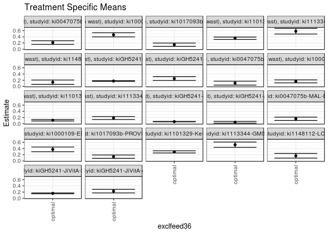

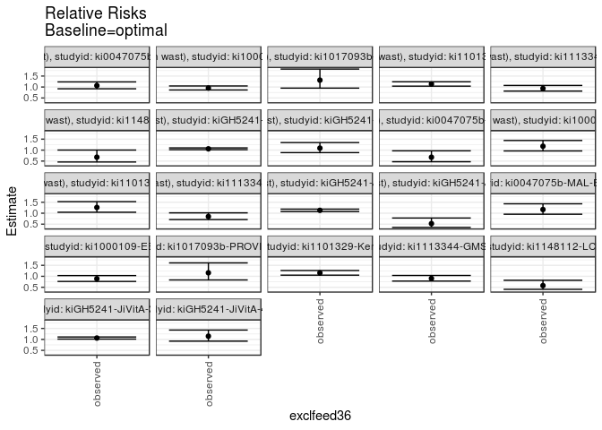

## Results Table

### Parameter: TSM

| agecat | studyid | country | intervention_level | baseline_level | estimate | ci_lower | ci_upper |
| --- | --- | --- | --- | --- | --- | --- | --- |
| 0-24 months (no birth wast) | ki0047075b-MAL-ED | BANGLADESH | optimal | NA | 0.2132706 | 0.1542238 | 0.2723174 |
| 0-24 months (no birth wast) | ki1000109-EE | PAKISTAN | optimal | NA | 0.4641204 | 0.3975360 | 0.5307047 |
| 0-24 months (no birth wast) | ki1017093b-PROVIDE | BANGLADESH | optimal | NA | 0.1437514 | 0.0904695 | 0.1970334 |
| 0-24 months (no birth wast) | ki1101329-Keneba | GAMBIA | optimal | NA | 0.3544096 | 0.3170674 | 0.3917518 |
| 0-24 months (no birth wast) | ki1113344-GMS-Nepal | NEPAL | optimal | NA | 0.5795862 | 0.4898723 | 0.6693001 |
| 0-24 months (no birth wast) | ki1148112-LCNI-5 | MALAWI | optimal | NA | 0.1361948 | 0.0650800 | 0.2073096 |
| 0-24 months (no birth wast) | kiGH5241-JiVitA-3 | BANGLADESH | optimal | NA | 0.1747970 | 0.1637203 | 0.1858737 |
| 0-24 months (no birth wast) | kiGH5241-JiVitA-4 | BANGLADESH | optimal | NA | 0.2540318 | 0.1923186 | 0.3157451 |
| 0-6 months (no birth wast) | ki0047075b-MAL-ED | BANGLADESH | optimal | NA | 0.1067792 | 0.0441777 | 0.1693806 |
| 0-6 months (no birth wast) | ki1000109-EE | PAKISTAN | optimal | NA | 0.1644390 | 0.1162255 | 0.2126524 |
| 0-6 months (no birth wast) | ki1101329-Keneba | GAMBIA | optimal | NA | 0.1111379 | 0.0865353 | 0.1357404 |
| 0-6 months (no birth wast) | ki1113344-GMS-Nepal | NEPAL | optimal | NA | 0.1829446 | 0.1352748 | 0.2306143 |
| 0-6 months (no birth wast) | kiGH5241-JiVitA-3 | BANGLADESH | optimal | NA | 0.0674263 | 0.0610141 | 0.0738385 |
| 0-6 months (no birth wast) | kiGH5241-JiVitA-4 | BANGLADESH | optimal | NA | 0.0466567 | 0.0194671 | 0.0738463 |
| 6-24 months | ki0047075b-MAL-ED | BANGLADESH | optimal | NA | 0.1576189 | 0.1034800 | 0.2117579 |
| 6-24 months | ki1000109-EE | PAKISTAN | optimal | NA | 0.3738937 | 0.2971187 | 0.4506687 |
| 6-24 months | ki1017093b-PROVIDE | BANGLADESH | optimal | NA | 0.1393228 | 0.0859310 | 0.1927146 |
| 6-24 months | ki1101329-Keneba | GAMBIA | optimal | NA | 0.2933985 | 0.2592477 | 0.3275493 |
| 6-24 months | ki1113344-GMS-Nepal | NEPAL | optimal | NA | 0.5252090 | 0.4397850 | 0.6106330 |
| 6-24 months | ki1148112-LCNI-5 | MALAWI | optimal | NA | 0.1681109 | 0.0917858 | 0.2444360 |
| 6-24 months | kiGH5241-JiVitA-3 | BANGLADESH | optimal | NA | 0.1572067 | 0.1449941 | 0.1694194 |
| 6-24 months | kiGH5241-JiVitA-4 | BANGLADESH | optimal | NA | 0.2291158 | 0.1710860 | 0.2871455 |

### Parameter: E(Y)

| agecat | studyid | country | intervention_level | baseline_level | estimate | ci_lower | ci_upper |
| --- | --- | --- | --- | --- | --- | --- | --- |
| 0-24 months (no birth wast) | ki0047075b-MAL-ED | BANGLADESH | observed | NA | 0.2270916 | 0.1751587 | 0.2790245 |
| 0-24 months (no birth wast) | ki1000109-EE | PAKISTAN | observed | NA | 0.4420485 | 0.3914450 | 0.4926520 |
| 0-24 months (no birth wast) | ki1017093b-PROVIDE | BANGLADESH | observed | NA | 0.1889764 | 0.1585028 | 0.2194500 |
| 0-24 months (no birth wast) | ki1101329-Keneba | GAMBIA | observed | NA | 0.4023279 | 0.3807014 | 0.4239544 |
| 0-24 months (no birth wast) | ki1113344-GMS-Nepal | NEPAL | observed | NA | 0.5414258 | 0.4985159 | 0.5843357 |
| 0-24 months (no birth wast) | ki1148112-LCNI-5 | MALAWI | observed | NA | 0.0922509 | 0.0577338 | 0.1267680 |
| 0-24 months (no birth wast) | kiGH5241-JiVitA-3 | BANGLADESH | observed | NA | 0.1850605 | 0.1758355 | 0.1942855 |
| 0-24 months (no birth wast) | kiGH5241-JiVitA-4 | BANGLADESH | observed | NA | 0.2770154 | 0.2466624 | 0.3073685 |
| 0-6 months (no birth wast) | ki0047075b-MAL-ED | BANGLADESH | observed | NA | 0.0720000 | 0.0398938 | 0.1041062 |
| 0-6 months (no birth wast) | ki1000109-EE | PAKISTAN | observed | NA | 0.1934605 | 0.1529920 | 0.2339289 |
| 0-6 months (no birth wast) | ki1101329-Keneba | GAMBIA | observed | NA | 0.1403152 | 0.1249627 | 0.1556677 |
| 0-6 months (no birth wast) | ki1113344-GMS-Nepal | NEPAL | observed | NA | 0.1553785 | 0.1236568 | 0.1871001 |
| 0-6 months (no birth wast) | kiGH5241-JiVitA-3 | BANGLADESH | observed | NA | 0.0762218 | 0.0701778 | 0.0822658 |
| 0-6 months (no birth wast) | kiGH5241-JiVitA-4 | BANGLADESH | observed | NA | 0.0245184 | 0.0133341 | 0.0357026 |
| 6-24 months | ki0047075b-MAL-ED | BANGLADESH | observed | NA | 0.1841004 | 0.1348619 | 0.2333390 |
| 6-24 months | ki1000109-EE | PAKISTAN | observed | NA | 0.3324324 | 0.2843668 | 0.3804980 |
| 6-24 months | ki1017093b-PROVIDE | BANGLADESH | observed | NA | 0.1615008 | 0.1323459 | 0.1906557 |
| 6-24 months | ki1101329-Keneba | GAMBIA | observed | NA | 0.3382353 | 0.3169789 | 0.3594917 |
| 6-24 months | ki1113344-GMS-Nepal | NEPAL | observed | NA | 0.4733840 | 0.4306748 | 0.5160933 |
| 6-24 months | ki1148112-LCNI-5 | MALAWI | observed | NA | 0.0968992 | 0.0607324 | 0.1330660 |
| 6-24 months | kiGH5241-JiVitA-3 | BANGLADESH | observed | NA | 0.1668622 | 0.1564951 | 0.1772292 |
| 6-24 months | kiGH5241-JiVitA-4 | BANGLADESH | observed | NA | 0.2625746 | 0.2327873 | 0.2923619 |

### Parameter: RR

| agecat | studyid | country | intervention_level | baseline_level | estimate | ci_lower | ci_upper |
| --- | --- | --- | --- | --- | --- | --- | --- |
| 0-24 months (no birth wast) | ki0047075b-MAL-ED | BANGLADESH | observed | optimal | 1.0648053 | 0.9198568 | 1.2325943 |
| 0-24 months (no birth wast) | ki1000109-EE | PAKISTAN | observed | optimal | 0.9524437 | 0.8648674 | 1.0488880 |
| 0-24 months (no birth wast) | ki1017093b-PROVIDE | BANGLADESH | observed | optimal | 1.3146054 | 0.9499714 | 1.8191993 |
| 0-24 months (no birth wast) | ki1101329-Keneba | GAMBIA | observed | optimal | 1.1352060 | 1.0407129 | 1.2382788 |
| 0-24 months (no birth wast) | ki1113344-GMS-Nepal | NEPAL | observed | optimal | 0.9341592 | 0.8146083 | 1.0712552 |
| 0-24 months (no birth wast) | ki1148112-LCNI-5 | MALAWI | observed | optimal | 0.6773453 | 0.4577078 | 1.0023790 |
| 0-24 months (no birth wast) | kiGH5241-JiVitA-3 | BANGLADESH | observed | optimal | 1.0587168 | 1.0189166 | 1.1000716 |
| 0-24 months (no birth wast) | kiGH5241-JiVitA-4 | BANGLADESH | observed | optimal | 1.0904753 | 0.8854443 | 1.3429826 |
| 0-6 months (no birth wast) | ki0047075b-MAL-ED | BANGLADESH | observed | optimal | 0.6742889 | 0.4701962 | 0.9669698 |
| 0-6 months (no birth wast) | ki1000109-EE | PAKISTAN | observed | optimal | 1.1764880 | 0.9622880 | 1.4383678 |
| 0-6 months (no birth wast) | ki1101329-Keneba | GAMBIA | observed | optimal | 1.2625328 | 1.0440341 | 1.5267597 |
| 0-6 months (no birth wast) | ki1113344-GMS-Nepal | NEPAL | observed | optimal | 0.8493201 | 0.7100217 | 1.0159472 |
| 0-6 months (no birth wast) | kiGH5241-JiVitA-3 | BANGLADESH | observed | optimal | 1.1304459 | 1.0761534 | 1.1874775 |
| 0-6 months (no birth wast) | kiGH5241-JiVitA-4 | BANGLADESH | observed | optimal | 0.5255062 | 0.3536092 | 0.7809661 |
| 6-24 months | ki0047075b-MAL-ED | BANGLADESH | observed | optimal | 1.1680094 | 0.9540519 | 1.4299495 |
| 6-24 months | ki1000109-EE | PAKISTAN | observed | optimal | 0.8891095 | 0.7656512 | 1.0324749 |
| 6-24 months | ki1017093b-PROVIDE | BANGLADESH | observed | optimal | 1.1591843 | 0.8337885 | 1.6115698 |
| 6-24 months | ki1101329-Keneba | GAMBIA | observed | optimal | 1.1528187 | 1.0511727 | 1.2642937 |
| 6-24 months | ki1113344-GMS-Nepal | NEPAL | observed | optimal | 0.9013250 | 0.7823917 | 1.0383376 |
| 6-24 months | ki1148112-LCNI-5 | MALAWI | observed | optimal | 0.5764006 | 0.4058701 | 0.8185813 |
| 6-24 months | kiGH5241-JiVitA-3 | BANGLADESH | observed | optimal | 1.0614186 | 1.0151865 | 1.1097562 |
| 6-24 months | kiGH5241-JiVitA-4 | BANGLADESH | observed | optimal | 1.1460345 | 0.9208417 | 1.4262986 |

### Parameter: PAR

| agecat | studyid | country | intervention_level | baseline_level | estimate | ci_lower | ci_upper |
| --- | --- | --- | --- | --- | --- | --- | --- |
| 0-24 months (no birth wast) | ki0047075b-MAL-ED | BANGLADESH | optimal | NA | 0.0138211 | -0.0174077 | 0.0450498 |
| 0-24 months (no birth wast) | ki1000109-EE | PAKISTAN | optimal | NA | -0.0220718 | -0.0667006 | 0.0225570 |
| 0-24 months (no birth wast) | ki1017093b-PROVIDE | BANGLADESH | optimal | NA | 0.0452250 | -0.0016363 | 0.0920863 |
| 0-24 months (no birth wast) | ki1101329-Keneba | GAMBIA | optimal | NA | 0.0479183 | 0.0171913 | 0.0786453 |
| 0-24 months (no birth wast) | ki1113344-GMS-Nepal | NEPAL | optimal | NA | -0.0381604 | -0.1174366 | 0.0411158 |
| 0-24 months (no birth wast) | ki1148112-LCNI-5 | MALAWI | optimal | NA | -0.0439439 | -0.0986649 | 0.0107771 |
| 0-24 months (no birth wast) | kiGH5241-JiVitA-3 | BANGLADESH | optimal | NA | 0.0102635 | 0.0035545 | 0.0169725 |
| 0-24 months (no birth wast) | kiGH5241-JiVitA-4 | BANGLADESH | optimal | NA | 0.0229836 | -0.0297854 | 0.0757526 |
| 0-6 months (no birth wast) | ki0047075b-MAL-ED | BANGLADESH | optimal | NA | -0.0347792 | -0.0769421 | 0.0073838 |
| 0-6 months (no birth wast) | ki1000109-EE | PAKISTAN | optimal | NA | 0.0290215 | -0.0044503 | 0.0624933 |
| 0-6 months (no birth wast) | ki1101329-Keneba | GAMBIA | optimal | NA | 0.0291773 | 0.0078883 | 0.0504664 |
| 0-6 months (no birth wast) | ki1113344-GMS-Nepal | NEPAL | optimal | NA | -0.0275661 | -0.0603700 | 0.0052379 |
| 0-6 months (no birth wast) | kiGH5241-JiVitA-3 | BANGLADESH | optimal | NA | 0.0087955 | 0.0054336 | 0.0121573 |
| 0-6 months (no birth wast) | kiGH5241-JiVitA-4 | BANGLADESH | optimal | NA | -0.0221383 | -0.0425682 | -0.0017084 |
| 6-24 months | ki0047075b-MAL-ED | BANGLADESH | optimal | NA | 0.0264815 | -0.0058342 | 0.0587972 |
| 6-24 months | ki1000109-EE | PAKISTAN | optimal | NA | -0.0414613 | -0.0975261 | 0.0146036 |
| 6-24 months | ki1017093b-PROVIDE | BANGLADESH | optimal | NA | 0.0221780 | -0.0237103 | 0.0680663 |
| 6-24 months | ki1101329-Keneba | GAMBIA | optimal | NA | 0.0448368 | 0.0178708 | 0.0718028 |
| 6-24 months | ki1113344-GMS-Nepal | NEPAL | optimal | NA | -0.0518250 | -0.1259811 | 0.0223311 |
| 6-24 months | ki1148112-LCNI-5 | MALAWI | optimal | NA | -0.0712117 | -0.1304628 | -0.0119606 |
| 6-24 months | kiGH5241-JiVitA-3 | BANGLADESH | optimal | NA | 0.0096554 | 0.0026495 | 0.0166614 |
| 6-24 months | kiGH5241-JiVitA-4 | BANGLADESH | optimal | NA | 0.0334588 | -0.0165482 | 0.0834659 |

### Parameter: PAF

| agecat | studyid | country | intervention_level | baseline_level | estimate | ci_lower | ci_upper |
| --- | --- | --- | --- | --- | --- | --- | --- |
| 0-24 months (no birth wast) | ki0047075b-MAL-ED | BANGLADESH | optimal | NA | 0.0608611 | -0.0871258 | 0.1887030 |
| 0-24 months (no birth wast) | ki1000109-EE | PAKISTAN | optimal | NA | -0.0499308 | -0.1562467 | 0.0466094 |
| 0-24 months (no birth wast) | ki1017093b-PROVIDE | BANGLADESH | optimal | NA | 0.2393155 | -0.0526632 | 0.4503076 |
| 0-24 months (no birth wast) | ki1101329-Keneba | GAMBIA | optimal | NA | 0.1191026 | 0.0391202 | 0.1924274 |
| 0-24 months (no birth wast) | ki1113344-GMS-Nepal | NEPAL | optimal | NA | -0.0704813 | -0.2275838 | 0.0665156 |
| 0-24 months (no birth wast) | ki1148112-LCNI-5 | MALAWI | optimal | NA | -0.4763518 | -1.1848001 | 0.0023734 |
| 0-24 months (no birth wast) | kiGH5241-JiVitA-3 | BANGLADESH | optimal | NA | 0.0554603 | 0.0185654 | 0.0909683 |
| 0-24 months (no birth wast) | kiGH5241-JiVitA-4 | BANGLADESH | optimal | NA | 0.0829687 | -0.1293765 | 0.2553887 |
| 0-6 months (no birth wast) | ki0047075b-MAL-ED | BANGLADESH | optimal | NA | -0.4830439 | -1.1267719 | -0.0341585 |
| 0-6 months (no birth wast) | ki1000109-EE | PAKISTAN | optimal | NA | 0.1500126 | -0.0391899 | 0.3047676 |
| 0-6 months (no birth wast) | ki1101329-Keneba | GAMBIA | optimal | NA | 0.2079414 | 0.0421769 | 0.3450181 |
| 0-6 months (no birth wast) | ki1113344-GMS-Nepal | NEPAL | optimal | NA | -0.1774124 | -0.4084076 | 0.0156968 |
| 0-6 months (no birth wast) | kiGH5241-JiVitA-3 | BANGLADESH | optimal | NA | 0.1153933 | 0.0707644 | 0.1578788 |
| 0-6 months (no birth wast) | kiGH5241-JiVitA-4 | BANGLADESH | optimal | NA | -0.9029271 | -1.8279810 | -0.2804653 |
| 6-24 months | ki0047075b-MAL-ED | BANGLADESH | optimal | NA | 0.1438425 | -0.0481610 | 0.3006746 |
| 6-24 months | ki1000109-EE | PAKISTAN | optimal | NA | -0.1247209 | -0.3060777 | 0.0314535 |
| 6-24 months | ki1017093b-PROVIDE | BANGLADESH | optimal | NA | 0.1373244 | -0.1993450 | 0.3794870 |
| 6-24 months | ki1101329-Keneba | GAMBIA | optimal | NA | 0.1325609 | 0.0486816 | 0.2090445 |
| 6-24 months | ki1113344-GMS-Nepal | NEPAL | optimal | NA | -0.1094777 | -0.2781321 | 0.0369221 |
| 6-24 months | ki1148112-LCNI-5 | MALAWI | optimal | NA | -0.7349045 | -1.4638425 | -0.2216258 |
| 6-24 months | kiGH5241-JiVitA-3 | BANGLADESH | optimal | NA | 0.0578647 | 0.0149593 | 0.0989012 |
| 6-24 months | kiGH5241-JiVitA-4 | BANGLADESH | optimal | NA | 0.1274259 | -0.0859630 | 0.2988845 |